# LAB 6[2]:계절성이 있는 자료에서의 Seasonal ARIMA 모형 적합 2

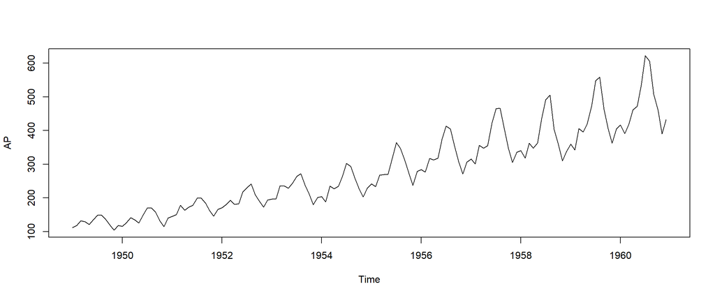

```r
> data("AirPassengers")
> AP<-AirPassengers
> ts.plot(AP)
```

뚜렷한 계절성과 선형추세가 관찰됨. 분산은 안정화 필요.

계절성이 뚜렷하여 sample 자기상관계수 값은 주기의 배수 부분에서 천천히 감소할 것으로 예상됨($\Longrightarrow$계절차분 필요). 또한 선형추세가 있기 때문에 계절차분후에는 기대값이 0이 아닌 시계열형태가 될 것으로 예상됨.

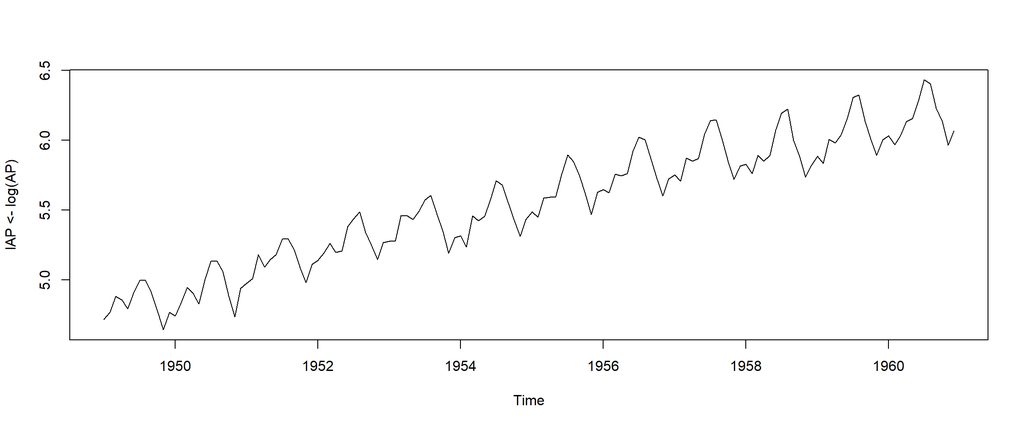

```r
> ts.plot(lAP<-log(AP))
```

### 모형식별

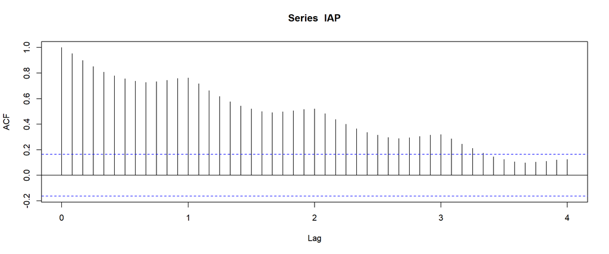

```r
> acf(lAP,lag.max=48)
```

예상했던 바와 같이, lag 1년, 2년, 3년에서의 sample 자기상관계수 값이 천천히(?) 감소함.

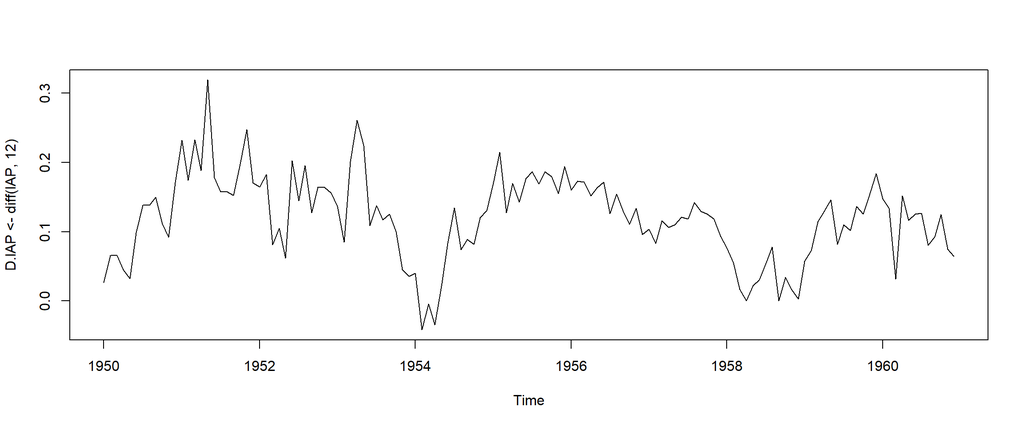

```r
> ts.plot(D.lAP<-diff(lAP, 12))
```

계절 차분된 자료는 평균이 0이 아닌 시계열로 보임.

정상 시계열 ? 확률적 추세를 보이는 시계열?

SACF와 SPACF 등으로 판단하면

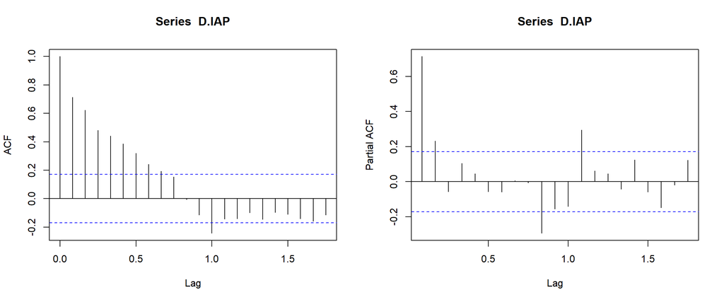

```r
> layout(t(1:2))
> acf(D.lAP )
> pacf(D.lAP)
```

ARMA모형의 ACF는 지수적으로 감소함. 위 Sample ACF는 지수적으로 감소하는 형태라고 볼 수 있는가??

위 자료는 선형으로 감소하는 형태로 판단되므로, 확률적 추세로 보고 추가적으로 차분 수행

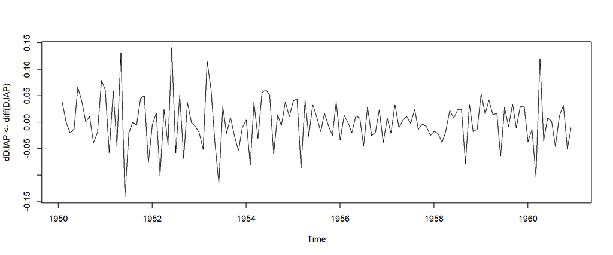

```r
> ts.plot(dD.lAP<-diff(D.lAP))
```

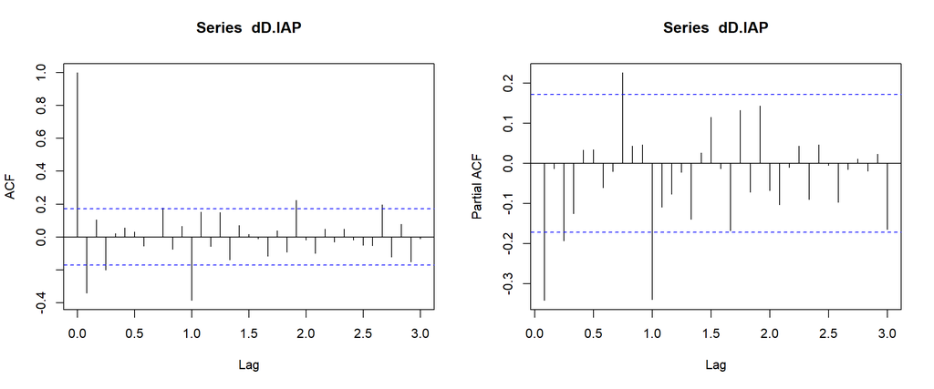

```r
> layout(t(1:2))
> acf(dD.lAP, lag.max = 36); pacf(dD.lAP, lag.max = 36)
```

Lag 12에서 sample 자기상관계수와 Lag 12,24 등에서 sample 부분자기상관계수 값들이 유의하면서 빠르게 감소하고, 인접한 값들 사이의 관계또 존재하고 있으므로, 위 $\{\bigtriangledown\bigtriangledown^{12} \log X_t\}$는 다음의 승법계절 ARIMA모형을 적합할 수 있는 정상시계열자료로 판단됨.
$$\{\bigtriangledown\bigtriangledown^{12} \log X_t\} \sim ARIMA(p,0,q)(P,0,Q)_{12}$$
$$\Longleftrightarrow \{\log X_t\} \sim ARIMA(p,1,q)(P,1,Q)_{12}$$
차분된 자료 $\{\bigtriangledown\bigtriangledown^{12} X_t\}$를 이용하여 차수 p,q,P,Q를 결정(여기서는 AIC를 기준으로 선택하고자 함).

```r
> library(forecast)
> aic<-1000
> for(p in 0:2) for(q in 0:2)for(P in 0:2) for(Q in 0:2){
+   try({aic.tmp<-AIC(Arima(lAP, order=c(p,1,q), seasonal = list(order = c(P, 1,Q), period = 12)))}, TRUE)
+   if(aic.tmp<aic){
+     aic<-aic.tmp
+     cat("p=",p, "q=",q, "P=",P,"Q=",Q," AIC=",aic ,"\n")
+    }
+ }
```

```
p= 0 q= 0 P= 0 Q= 0  AIC= -434.83
p= 0 q= 0 P= 0 Q= 1  AIC= -467.5581
p= 0 q= 1 P= 0 Q= 1  AIC= -483.3991
```

AIC기준으로 다음의 $ARIMA(0,1,1)(0,1,1)_{12}$모형이 잠정모형으로 선택됨.
$$\log X_t = (1-\theta B)(1-\Theta B^{12}) e_t,$$
여기서 $\{e_t\} \sim W.N (0,\sigma^2)$.

### 잔차분석

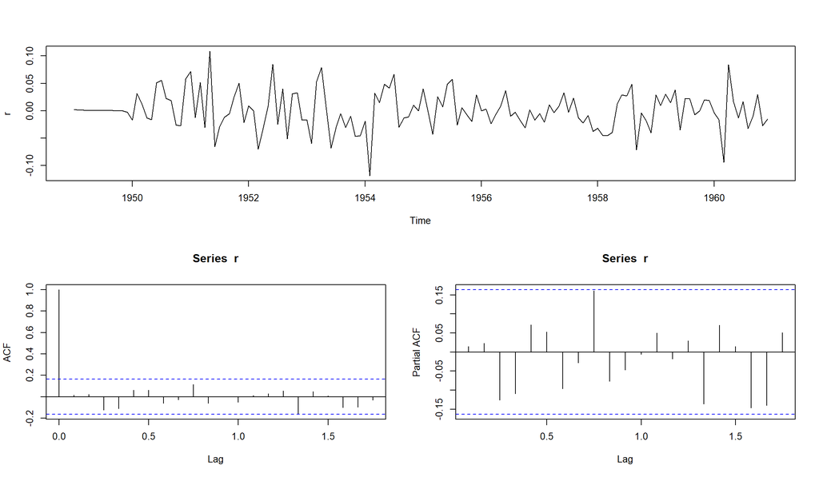

```r
> library(forecast)
> lAP.fit<-Arima(lAP, order=c(0,1,1), seasonal = list(order = c(0, 1, 1), period = 12))
> r<-lAP.fit$res
> layout(matrix(c(1,2,1,3),2,2))
> ts.plot(r); acf(r); pacf(r)
```

```r
> Box.test(r, lag=12, type="Ljung") # 잔차의 자기상관계수가 12시차까지 0이라고 할 수 있는가?
```

```
    Box-Ljung test

data:  r
X-squared = 9.2333, df = 12, p-value = 0.6829
```

잔차 plot 및 잔차의 SACF와 SPACF, 그리고 Ljung-Box 결과 등을 살펴보면 잔차를 white noise로 간주해도 될 듯함. 잔차(모형화 후 남은 부분)에 모형화할 만한 종속관계가 더 이상 남아있지 않아 보임. 따라서, 위 잠정모형을 최종 모형으로 확정함.

### 모수추정결과

```r
> lAP.fit
```

```
Series: lAP
ARIMA(0,1,1)(0,1,1)[12]

Coefficients:
          ma1     sma1
      -0.4018  -0.5569
s.e.   0.0896   0.0731

sigma^2 estimated as 0.001371:  log likelihood=244.7
AIC=-483.4   AICc=-483.21   BIC=-474.77
```

$$\hat\theta=-0.402,\quad \hat\Theta=-0.557,\quad \hat\sigma^2=0.0013$$

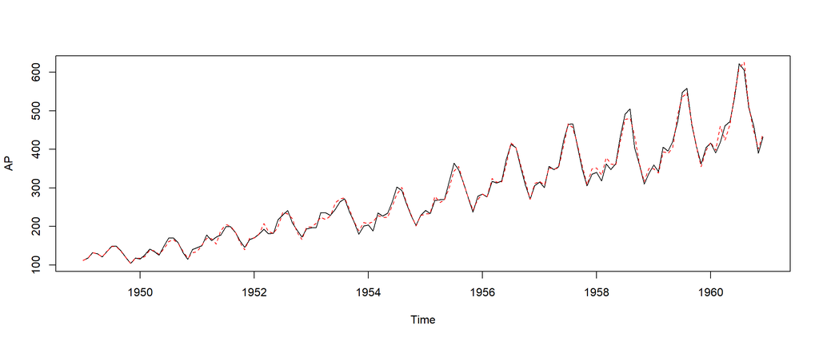

```r
> hat.lAP<-lAP.fit$fitted # 적합값(추정된 모형에 의해서 계산된 값)
> ts.plot(AP)
> lines(exp(hat.lAP), col="red", lty=2)
```

### 예측

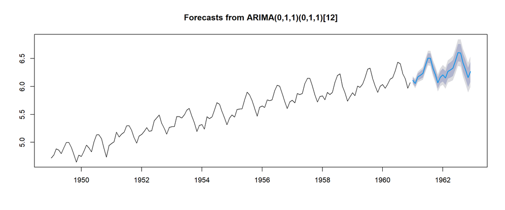

```r
> plot(forecast(lAP.fit, h=24))
```

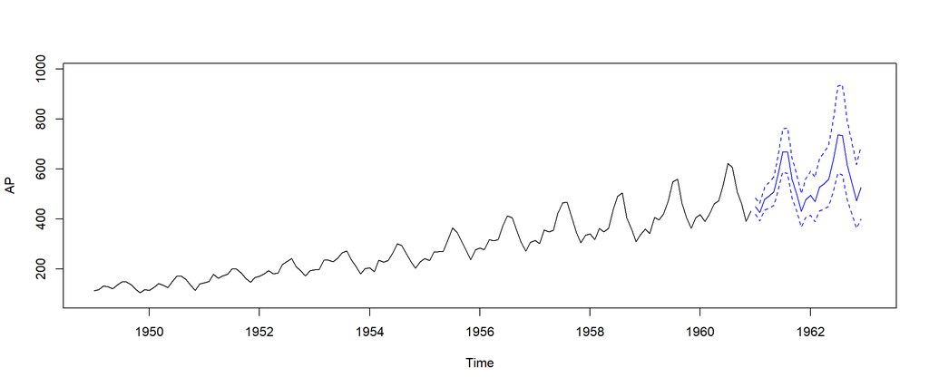

```r
> lAP.fore<-forecast(lAP.fit, h=24)
> AP.mean<-ts(exp(lAP.fore$mean), start=1961, freq=12)
> AP.U95<-ts(exp(lAP.fore$upper[,2]), start=1961, freq=12)
> AP.L95<-ts(exp(lAP.fore$lower[,2]), start=1961, freq=12)
> ts.plot(AP, xlim=c(1949,1960+3), ylim=c(80,max(AP.U95)+50))
> lines(AP.mean, col="blue")
> lines(AP.U95, col="blue", lty=2)
> lines(AP.L95, col="blue", lty=2)
```

### auto.arima

(이번 학기 끝날 때까지 사용금지. 참고로는 사용할 수 있음.)

```r
> auto.arima(lAP)
```

```
Series: lAP
ARIMA(0,1,1)(0,1,1)[12]

Coefficients:
          ma1     sma1
      -0.4018  -0.5569
s.e.   0.0896   0.0731

sigma^2 estimated as 0.001371:  log likelihood=244.7
AIC=-483.4   AICc=-483.21   BIC=-474.77
```

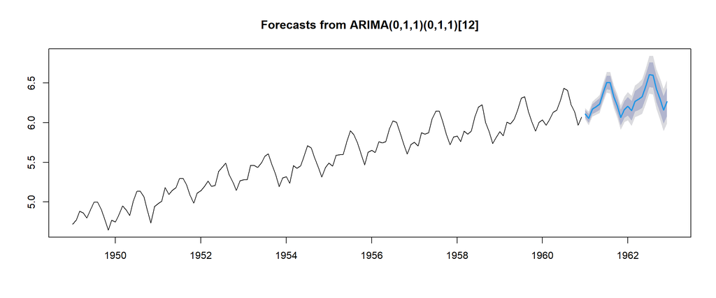

```r
> plot(forecast(auto.arima(lAP), h=24))
```

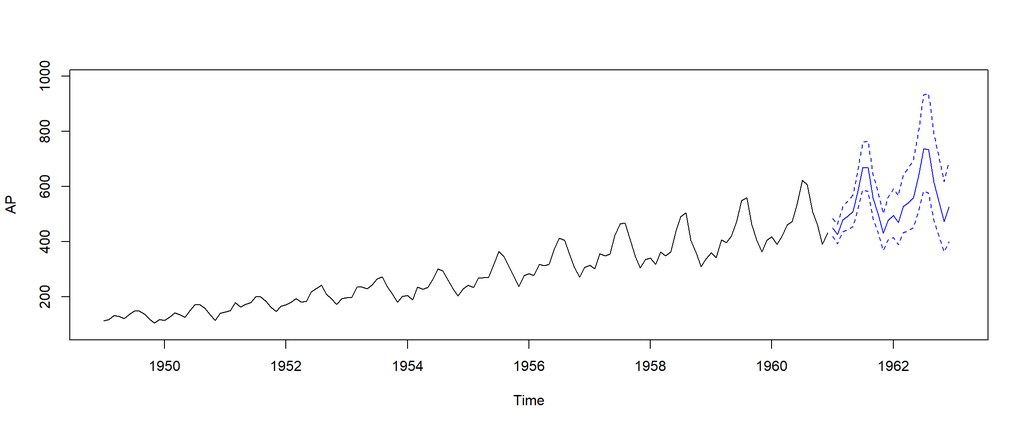

```r
> lAP.fore<-forecast(auto.arima(lAP),h=24)
> AP.mean<-ts(exp(lAP.fore$mean), start=1961, freq=12)
> AP.U95<-ts(exp(lAP.fore$upper[,2]), start=1961, freq=12)
> AP.L95<-ts(exp(lAP.fore$lower[,2]), start=1961, freq=12)
> ts.plot(AP, xlim=c(1949,1960+3), ylim=c(80,max(AP.U95)+50))
> lines(AP.mean, col="blue")
> lines(AP.U95, col="blue", lty=2)
> lines(AP.L95, col="blue", lty=2)
```